# Risk Factor Analysis

## Outcome Variable

**Outcome Variable:** ever_swasted

## Predictor Variables

**Intervention Variable:** vagbrth

**Adjustment Set:**

- arm
- sex
- W_mage
- meducyrs
- feducyrs
- hhwealth_quart
- W_mhtcm
- W_mwtkg
- W_mbmi
- single
- brthmon
- W_parity
- delta_W_mage
- delta_meducyrs
- delta_feducyrs
- delta_hhwealth_quart
- delta_W_mhtcm
- delta_W_mwtkg
- delta_W_mbmi
- delta_single
- delta_brthmon
- delta_W_parity

## Stratifying Variables

The analysis was stratified on these variable(s):

- agecat
- studyid
- country

## Data Summary

| agecat | studyid | country | vagbrth | ever_swasted | n_cell | n |
| --- | --- | --- | --- | --- | --- | --- |
| 0-24 months (no birth wast) | CMC-V-BCS-2002 | INDIA | 0 | 0 | 20 | 368 |
| 0-24 months (no birth wast) | CMC-V-BCS-2002 | INDIA | 0 | 1 | 5 | 368 |
| 0-24 months (no birth wast) | CMC-V-BCS-2002 | INDIA | 1 | 0 | 293 | 368 |
| 0-24 months (no birth wast) | CMC-V-BCS-2002 | INDIA | 1 | 1 | 50 | 368 |
| 0-24 months (no birth wast) | IRC | INDIA | 0 | 0 | 55 | 409 |
| 0-24 months (no birth wast) | IRC | INDIA | 0 | 1 | 15 | 409 |
| 0-24 months (no birth wast) | IRC | INDIA | 1 | 0 | 277 | 409 |
| 0-24 months (no birth wast) | IRC | INDIA | 1 | 1 | 62 | 409 |
| 0-24 months (no birth wast) | JiVitA-3 | BANGLADESH | 0 | 0 | 1454 | 26404 |
| 0-24 months (no birth wast) | JiVitA-3 | BANGLADESH | 0 | 1 | 36 | 26404 |
| 0-24 months (no birth wast) | JiVitA-3 | BANGLADESH | 1 | 0 | 24005 | 26404 |
| 0-24 months (no birth wast) | JiVitA-3 | BANGLADESH | 1 | 1 | 909 | 26404 |
| 0-24 months (no birth wast) | JiVitA-4 | BANGLADESH | 0 | 0 | 358 | 4499 |
| 0-24 months (no birth wast) | JiVitA-4 | BANGLADESH | 0 | 1 | 12 | 4499 |
| 0-24 months (no birth wast) | JiVitA-4 | BANGLADESH | 1 | 0 | 3933 | 4499 |
| 0-24 months (no birth wast) | JiVitA-4 | BANGLADESH | 1 | 1 | 196 | 4499 |
| 0-24 months (no birth wast) | NIH-Crypto | BANGLADESH | 0 | 0 | 198 | 496 |
| 0-24 months (no birth wast) | NIH-Crypto | BANGLADESH | 0 | 1 | 4 | 496 |
| 0-24 months (no birth wast) | NIH-Crypto | BANGLADESH | 1 | 0 | 284 | 496 |
| 0-24 months (no birth wast) | NIH-Crypto | BANGLADESH | 1 | 1 | 10 | 496 |
| 0-24 months (no birth wast) | PROBIT | BELARUS | 0 | 0 | 1926 | 16879 |
| 0-24 months (no birth wast) | PROBIT | BELARUS | 0 | 1 | 26 | 16879 |
| 0-24 months (no birth wast) | PROBIT | BELARUS | 1 | 0 | 14749 | 16879 |
| 0-24 months (no birth wast) | PROBIT | BELARUS | 1 | 1 | 178 | 16879 |
| 0-24 months (no birth wast) | PROVIDE | BANGLADESH | 0 | 0 | 158 | 687 |
| 0-24 months (no birth wast) | PROVIDE | BANGLADESH | 0 | 1 | 1 | 687 |
| 0-24 months (no birth wast) | PROVIDE | BANGLADESH | 1 | 0 | 510 | 687 |
| 0-24 months (no birth wast) | PROVIDE | BANGLADESH | 1 | 1 | 18 | 687 |
| 0-24 months (no birth wast) | TanzaniaChild2 | TANZANIA, UNITED REPUBLIC OF | 0 | 0 | 195 | 2355 |
| 0-24 months (no birth wast) | TanzaniaChild2 | TANZANIA, UNITED REPUBLIC OF | 0 | 1 | 17 | 2355 |

[output cut: 78 more lines]

The following strata were considered:

- agecat: 0-24 months (no birth wast), studyid: CMC-V-BCS-2002, country: INDIA
- agecat: 0-24 months (no birth wast), studyid: IRC, country: INDIA
- agecat: 0-24 months (no birth wast), studyid: JiVitA-3, country: BANGLADESH
- agecat: 0-24 months (no birth wast), studyid: JiVitA-4, country: BANGLADESH
- agecat: 0-24 months (no birth wast), studyid: NIH-Crypto, country: BANGLADESH
- agecat: 0-24 months (no birth wast), studyid: PROBIT, country: BELARUS
- agecat: 0-24 months (no birth wast), studyid: PROVIDE, country: BANGLADESH
- agecat: 0-24 months (no birth wast), studyid: TanzaniaChild2, country: TANZANIA, UNITED REPUBLIC OF
- agecat: 0-24 months (no birth wast), studyid: ZVITAMBO, country: ZIMBABWE
- agecat: 0-6 months (no birth wast), studyid: CMC-V-BCS-2002, country: INDIA
- agecat: 0-6 months (no birth wast), studyid: IRC, country: INDIA
- agecat: 0-6 months (no birth wast), studyid: JiVitA-3, country: BANGLADESH
- agecat: 0-6 months (no birth wast), studyid: JiVitA-4, country: BANGLADESH
- agecat: 0-6 months (no birth wast), studyid: NIH-Crypto, country: BANGLADESH
- agecat: 0-6 months (no birth wast), studyid: PROBIT, country: BELARUS
- agecat: 0-6 months (no birth wast), studyid: PROVIDE, country: BANGLADESH
- agecat: 0-6 months (no birth wast), studyid: TanzaniaChild2, country: TANZANIA, UNITED REPUBLIC OF
- agecat: 0-6 months (no birth wast), studyid: ZVITAMBO, country: ZIMBABWE
- agecat: 6-24 months, studyid: CMC-V-BCS-2002, country: INDIA
- agecat: 6-24 months, studyid: IRC, country: INDIA
- agecat: 6-24 months, studyid: JiVitA-3, country: BANGLADESH
- agecat: 6-24 months, studyid: JiVitA-4, country: BANGLADESH
- agecat: 6-24 months, studyid: NIH-Crypto, country: BANGLADESH
- agecat: 6-24 months, studyid: PROBIT, country: BELARUS
- agecat: 6-24 months, studyid: PROVIDE, country: BANGLADESH
- agecat: 6-24 months, studyid: TanzaniaChild2, country: TANZANIA, UNITED REPUBLIC OF
- agecat: 6-24 months, studyid: ZVITAMBO, country: ZIMBABWE

### Dropped Strata

Some strata were dropped due to rare outcomes:

- agecat: 0-24 months (no birth wast), studyid: NIH-Crypto, country: BANGLADESH
- agecat: 0-24 months (no birth wast), studyid: PROVIDE, country: BANGLADESH
- agecat: 0-6 months (no birth wast), studyid: CMC-V-BCS-2002, country: INDIA
- agecat: 0-6 months (no birth wast), studyid: JiVitA-4, country: BANGLADESH
- agecat: 0-6 months (no birth wast), studyid: NIH-Crypto, country: BANGLADESH
- agecat: 0-6 months (no birth wast), studyid: PROVIDE, country: BANGLADESH
- agecat: 0-6 months (no birth wast), studyid: ZVITAMBO, country: ZIMBABWE
- agecat: 6-24 months, studyid: CMC-V-BCS-2002, country: INDIA
- agecat: 6-24 months, studyid: IRC, country: INDIA
- agecat: 6-24 months, studyid: NIH-Crypto, country: BANGLADESH
- agecat: 6-24 months, studyid: PROBIT, country: BELARUS
- agecat: 6-24 months, studyid: PROVIDE, country: BANGLADESH

## Methods Detail

We’re interested in the causal parameters $E[Y_a]$ for all values of $a \in \mathcal{A}$. These parameters represent the mean outcome if, possibly contrary to fact, we intervened to set all units to have $A=a$. Under the randomization and positivity assumptions, these are identified by the statistical parameters $\psi_a=E_W[E_{Y|A,W}(Y|A=a,W)]$. In addition, we’re interested in the mean of $Y$, $E[Y]$ under no intervention (the observed mean). We will estimate these parameters by using SuperLearner to fit the relevant likelihood factors – $E_{Y|A,W}(Y|A=a,W)$ and $p(A=a|W)$, and then updating our likelihood fit using a joint TMLE.

For unadjusted analyses ($W=\{\}$), initial likelihoods were estimated using Lrnr_glm to estimate the simple $E(Y|A)$ and Lrnr_mean to estimate $p(A)$. For adjusted analyses, a small library containing Lrnr_glmnet, Lrnr_xgboost, and Lrnr_mean was used.

Having estimated these parameters, we will then use the delta method to estimate relative risks and attributable risks relative to a prespecified baseline level of $A$.

# Results Detail

## Results Plots

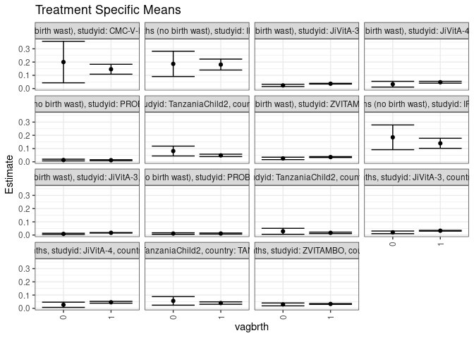

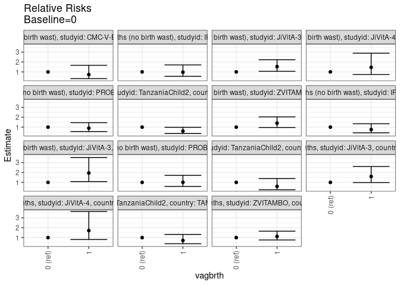

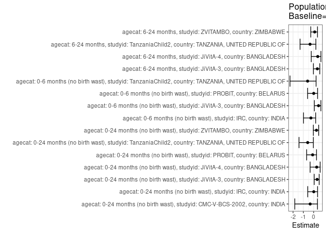

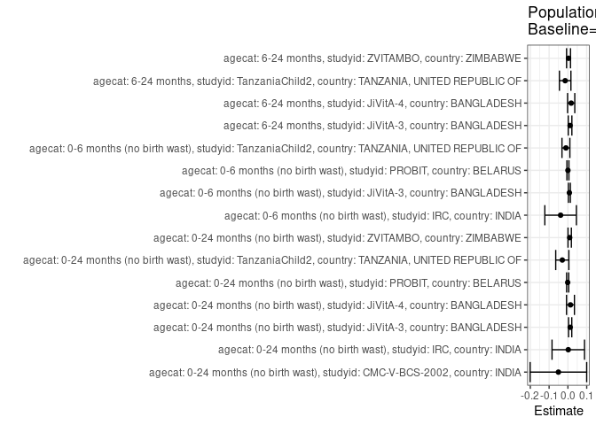

## Results Table

### Parameter: TSM

| agecat | studyid | country | intervention_level | baseline_level | estimate | ci_lower | ci_upper |
| --- | --- | --- | --- | --- | --- | --- | --- |
| 0-24 months (no birth wast) | CMC-V-BCS-2002 | INDIA | 0 | NA | 0.2000000 | 0.0429894 | 0.3570106 |
| 0-24 months (no birth wast) | CMC-V-BCS-2002 | INDIA | 1 | NA | 0.1457726 | 0.1083773 | 0.1831679 |
| 0-24 months (no birth wast) | IRC | INDIA | 0 | NA | 0.1863439 | 0.0907586 | 0.2819292 |
| 0-24 months (no birth wast) | IRC | INDIA | 1 | NA | 0.1810549 | 0.1398051 | 0.2223047 |
| 0-24 months (no birth wast) | JiVitA-3 | BANGLADESH | 0 | NA | 0.0237413 | 0.0150422 | 0.0324404 |
| 0-24 months (no birth wast) | JiVitA-3 | BANGLADESH | 1 | NA | 0.0364791 | 0.0337939 | 0.0391644 |
| 0-24 months (no birth wast) | JiVitA-4 | BANGLADESH | 0 | NA | 0.0325549 | 0.0109208 | 0.0541891 |
| 0-24 months (no birth wast) | JiVitA-4 | BANGLADESH | 1 | NA | 0.0474913 | 0.0405090 | 0.0544735 |
| 0-24 months (no birth wast) | PROBIT | BELARUS | 0 | NA | 0.0133220 | 0.0069738 | 0.0196702 |
| 0-24 months (no birth wast) | PROBIT | BELARUS | 1 | NA | 0.0119228 | 0.0079875 | 0.0158580 |
| 0-24 months (no birth wast) | TanzaniaChild2 | TANZANIA, UNITED REPUBLIC OF | 0 | NA | 0.0812251 | 0.0439851 | 0.1184651 |
| 0-24 months (no birth wast) | TanzaniaChild2 | TANZANIA, UNITED REPUBLIC OF | 1 | NA | 0.0484541 | 0.0393590 | 0.0575492 |
| 0-24 months (no birth wast) | ZVITAMBO | ZIMBABWE | 0 | NA | 0.0254298 | 0.0162257 | 0.0346339 |
| 0-24 months (no birth wast) | ZVITAMBO | ZIMBABWE | 1 | NA | 0.0356689 | 0.0323977 | 0.0389400 |
| 0-6 months (no birth wast) | IRC | INDIA | 0 | NA | 0.1849692 | 0.0914605 | 0.2784779 |
| 0-6 months (no birth wast) | IRC | INDIA | 1 | NA | 0.1396978 | 0.1017980 | 0.1775976 |
| 0-6 months (no birth wast) | JiVitA-3 | BANGLADESH | 0 | NA | 0.0087718 | 0.0037349 | 0.0138087 |
| 0-6 months (no birth wast) | JiVitA-3 | BANGLADESH | 1 | NA | 0.0170885 | 0.0151719 | 0.0190051 |
| 0-6 months (no birth wast) | PROBIT | BELARUS | 0 | NA | 0.0114342 | 0.0057683 | 0.0171001 |
| 0-6 months (no birth wast) | PROBIT | BELARUS | 1 | NA | 0.0115123 | 0.0074952 | 0.0155295 |
| 0-6 months (no birth wast) | TanzaniaChild2 | TANZANIA, UNITED REPUBLIC OF | 0 | NA | 0.0284360 | 0.0060039 | 0.0508681 |
| 0-6 months (no birth wast) | TanzaniaChild2 | TANZANIA, UNITED REPUBLIC OF | 1 | NA | 0.0168539 | 0.0113938 | 0.0223140 |
| 6-24 months | JiVitA-3 | BANGLADESH | 0 | NA | 0.0204855 | 0.0106376 | 0.0303334 |
| 6-24 months | JiVitA-3 | BANGLADESH | 1 | NA | 0.0327367 | 0.0297211 | 0.0357523 |
| 6-24 months | JiVitA-4 | BANGLADESH | 0 | NA | 0.0266574 | 0.0069695 | 0.0463453 |
| 6-24 months | JiVitA-4 | BANGLADESH | 1 | NA | 0.0456937 | 0.0386688 | 0.0527186 |
| 6-24 months | TanzaniaChild2 | TANZANIA, UNITED REPUBLIC OF | 0 | NA | 0.0561393 | 0.0236075 | 0.0886711 |
| 6-24 months | TanzaniaChild2 | TANZANIA, UNITED REPUBLIC OF | 1 | NA | 0.0397876 | 0.0307839 | 0.0487913 |
| 6-24 months | ZVITAMBO | ZIMBABWE | 0 | NA | 0.0293995 | 0.0185029 | 0.0402961 |
| 6-24 months | ZVITAMBO | ZIMBABWE | 1 | NA | 0.0329757 | 0.0294406 | 0.0365108 |

### Parameter: E(Y)

| agecat | studyid | country | intervention_level | baseline_level | estimate | ci_lower | ci_upper |
| --- | --- | --- | --- | --- | --- | --- | --- |
| 0-24 months (no birth wast) | CMC-V-BCS-2002 | INDIA | NA | NA | 0.1494565 | 0.1129794 | 0.1859337 |
| 0-24 months (no birth wast) | IRC | INDIA | NA | NA | 0.1882641 | 0.1503318 | 0.2261964 |
| 0-24 months (no birth wast) | JiVitA-3 | BANGLADESH | NA | NA | 0.0357900 | 0.0332085 | 0.0383715 |
| 0-24 months (no birth wast) | JiVitA-4 | BANGLADESH | NA | NA | 0.0462325 | 0.0396215 | 0.0528435 |
| 0-24 months (no birth wast) | PROBIT | BELARUS | NA | NA | 0.0120860 | 0.0083142 | 0.0158578 |
| 0-24 months (no birth wast) | TanzaniaChild2 | TANZANIA, UNITED REPUBLIC OF | NA | NA | 0.0513800 | 0.0424616 | 0.0602985 |
| 0-24 months (no birth wast) | ZVITAMBO | ZIMBABWE | NA | NA | 0.0349061 | 0.0318124 | 0.0379998 |
| 0-6 months (no birth wast) | IRC | INDIA | NA | NA | 0.1461538 | 0.1110489 | 0.1812588 |
| 0-6 months (no birth wast) | JiVitA-3 | BANGLADESH | NA | NA | 0.0166323 | 0.0148114 | 0.0184531 |
| 0-6 months (no birth wast) | PROBIT | BELARUS | NA | NA | 0.0115018 | 0.0077384 | 0.0152653 |
| 0-6 months (no birth wast) | TanzaniaChild2 | TANZANIA, UNITED REPUBLIC OF | NA | NA | 0.0178952 | 0.0125307 | 0.0232597 |
| 6-24 months | JiVitA-3 | BANGLADESH | NA | NA | 0.0319545 | 0.0290590 | 0.0348499 |
| 6-24 months | JiVitA-4 | BANGLADESH | NA | NA | 0.0441242 | 0.0374527 | 0.0507956 |
| 6-24 months | TanzaniaChild2 | TANZANIA, UNITED REPUBLIC OF | NA | NA | 0.0415832 | 0.0328230 | 0.0503433 |
| 6-24 months | ZVITAMBO | ZIMBABWE | NA | NA | 0.0327334 | 0.0293653 | 0.0361014 |

### Parameter: RR

| agecat | studyid | country | intervention_level | baseline_level | estimate | ci_lower | ci_upper |
| --- | --- | --- | --- | --- | --- | --- | --- |
| 0-24 months (no birth wast) | CMC-V-BCS-2002 | INDIA | 0 | 0 | 1.0000000 | 1.0000000 | 1.0000000 |
| 0-24 months (no birth wast) | CMC-V-BCS-2002 | INDIA | 1 | 0 | 0.7288630 | 0.3191248 | 1.6646817 |
| 0-24 months (no birth wast) | IRC | INDIA | 0 | 0 | 1.0000000 | 1.0000000 | 1.0000000 |
| 0-24 months (no birth wast) | IRC | INDIA | 1 | 0 | 0.9716172 | 0.5544675 | 1.7026068 |
| 0-24 months (no birth wast) | JiVitA-3 | BANGLADESH | 0 | 0 | 1.0000000 | 1.0000000 | 1.0000000 |
| 0-24 months (no birth wast) | JiVitA-3 | BANGLADESH | 1 | 0 | 1.5365279 | 1.0583242 | 2.2308080 |
| 0-24 months (no birth wast) | JiVitA-4 | BANGLADESH | 0 | 0 | 1.0000000 | 1.0000000 | 1.0000000 |
| 0-24 months (no birth wast) | JiVitA-4 | BANGLADESH | 1 | 0 | 1.4588043 | 0.7358134 | 2.8921872 |
| 0-24 months (no birth wast) | PROBIT | BELARUS | 0 | 0 | 1.0000000 | 1.0000000 | 1.0000000 |
| 0-24 months (no birth wast) | PROBIT | BELARUS | 1 | 0 | 0.8949668 | 0.5505879 | 1.4547459 |
| 0-24 months (no birth wast) | TanzaniaChild2 | TANZANIA, UNITED REPUBLIC OF | 0 | 0 | 1.0000000 | 1.0000000 | 1.0000000 |
| 0-24 months (no birth wast) | TanzaniaChild2 | TANZANIA, UNITED REPUBLIC OF | 1 | 0 | 0.5965412 | 0.3635529 | 0.9788434 |
| 0-24 months (no birth wast) | ZVITAMBO | ZIMBABWE | 0 | 0 | 1.0000000 | 1.0000000 | 1.0000000 |
| 0-24 months (no birth wast) | ZVITAMBO | ZIMBABWE | 1 | 0 | 1.4026390 | 0.9656209 | 2.0374417 |
| 0-6 months (no birth wast) | IRC | INDIA | 0 | 0 | 1.0000000 | 1.0000000 | 1.0000000 |
| 0-6 months (no birth wast) | IRC | INDIA | 1 | 0 | 0.7552488 | 0.4253429 | 1.3410376 |
| 0-6 months (no birth wast) | JiVitA-3 | BANGLADESH | 0 | 0 | 1.0000000 | 1.0000000 | 1.0000000 |
| 0-6 months (no birth wast) | JiVitA-3 | BANGLADESH | 1 | 0 | 1.9481132 | 1.0819525 | 3.5076817 |
| 0-6 months (no birth wast) | PROBIT | BELARUS | 0 | 0 | 1.0000000 | 1.0000000 | 1.0000000 |
| 0-6 months (no birth wast) | PROBIT | BELARUS | 1 | 0 | 1.0068343 | 0.5927255 | 1.7102610 |
| 0-6 months (no birth wast) | TanzaniaChild2 | TANZANIA, UNITED REPUBLIC OF | 0 | 0 | 1.0000000 | 1.0000000 | 1.0000000 |
| 0-6 months (no birth wast) | TanzaniaChild2 | TANZANIA, UNITED REPUBLIC OF | 1 | 0 | 0.5926966 | 0.2526208 | 1.3905792 |
| 6-24 months | JiVitA-3 | BANGLADESH | 0 | 0 | 1.0000000 | 1.0000000 | 1.0000000 |
| 6-24 months | JiVitA-3 | BANGLADESH | 1 | 0 | 1.5980426 | 0.9800614 | 2.6056939 |
| 6-24 months | JiVitA-4 | BANGLADESH | 0 | 0 | 1.0000000 | 1.0000000 | 1.0000000 |
| 6-24 months | JiVitA-4 | BANGLADESH | 1 | 0 | 1.7141086 | 0.8073018 | 3.6394920 |
| 6-24 months | TanzaniaChild2 | TANZANIA, UNITED REPUBLIC OF | 0 | 0 | 1.0000000 | 1.0000000 | 1.0000000 |
| 6-24 months | TanzaniaChild2 | TANZANIA, UNITED REPUBLIC OF | 1 | 0 | 0.7087299 | 0.3803918 | 1.3204755 |
| 6-24 months | ZVITAMBO | ZIMBABWE | 0 | 0 | 1.0000000 | 1.0000000 | 1.0000000 |
| 6-24 months | ZVITAMBO | ZIMBABWE | 1 | 0 | 1.1216418 | 0.7626062 | 1.6497117 |

### Parameter: PAR

| agecat | studyid | country | intervention_level | baseline_level | estimate | ci_lower | ci_upper |
| --- | --- | --- | --- | --- | --- | --- | --- |
| 0-24 months (no birth wast) | CMC-V-BCS-2002 | INDIA | 0 | NA | -0.0505435 | -0.2009875 | 0.0999006 |
| 0-24 months (no birth wast) | IRC | INDIA | 0 | NA | 0.0019202 | -0.0844900 | 0.0883304 |
| 0-24 months (no birth wast) | JiVitA-3 | BANGLADESH | 0 | NA | 0.0120488 | 0.0034877 | 0.0206098 |
| 0-24 months (no birth wast) | JiVitA-4 | BANGLADESH | 0 | NA | 0.0136776 | -0.0073462 | 0.0347013 |
| 0-24 months (no birth wast) | PROBIT | BELARUS | 0 | NA | -0.0012360 | -0.0068162 | 0.0043442 |
| 0-24 months (no birth wast) | TanzaniaChild2 | TANZANIA, UNITED REPUBLIC OF | 0 | NA | -0.0298451 | -0.0648018 | 0.0051117 |
| 0-24 months (no birth wast) | ZVITAMBO | ZIMBABWE | 0 | NA | 0.0094763 | 0.0005357 | 0.0184169 |
| 0-6 months (no birth wast) | IRC | INDIA | 0 | NA | -0.0388154 | -0.1227253 | 0.0450945 |
| 0-6 months (no birth wast) | JiVitA-3 | BANGLADESH | 0 | NA | 0.0078604 | 0.0027282 | 0.0129926 |
| 0-6 months (no birth wast) | PROBIT | BELARUS | 0 | NA | 0.0000676 | -0.0053067 | 0.0054420 |
| 0-6 months (no birth wast) | TanzaniaChild2 | TANZANIA, UNITED REPUBLIC OF | 0 | NA | -0.0105408 | -0.0315527 | 0.0104710 |
| 6-24 months | JiVitA-3 | BANGLADESH | 0 | NA | 0.0114690 | 0.0018536 | 0.0210844 |
| 6-24 months | JiVitA-4 | BANGLADESH | 0 | NA | 0.0174668 | -0.0016371 | 0.0365706 |
| 6-24 months | TanzaniaChild2 | TANZANIA, UNITED REPUBLIC OF | 0 | NA | -0.0145561 | -0.0451020 | 0.0159897 |
| 6-24 months | ZVITAMBO | ZIMBABWE | 0 | NA | 0.0033339 | -0.0071256 | 0.0137934 |

### Parameter: PAF

| agecat | studyid | country | intervention_level | baseline_level | estimate | ci_lower | ci_upper |
| --- | --- | --- | --- | --- | --- | --- | --- |
| 0-24 months (no birth wast) | CMC-V-BCS-2002 | INDIA | 0 | NA | -0.3381818 | -1.8354235 | 0.3684433 |
| 0-24 months (no birth wast) | IRC | INDIA | 0 | NA | 0.0101994 | -0.5738731 | 0.3775196 |
| 0-24 months (no birth wast) | JiVitA-3 | BANGLADESH | 0 | NA | 0.3366512 | 0.0502411 | 0.5366912 |
| 0-24 months (no birth wast) | JiVitA-4 | BANGLADESH | 0 | NA | 0.2958433 | -0.3418034 | 0.6304700 |
| 0-24 months (no birth wast) | PROBIT | BELARUS | 0 | NA | -0.1022659 | -0.6832016 | 0.2781672 |
| 0-24 months (no birth wast) | TanzaniaChild2 | TANZANIA, UNITED REPUBLIC OF | 0 | NA | -0.5808688 | -1.4213498 | -0.0321294 |
| 0-24 months (no birth wast) | ZVITAMBO | ZIMBABWE | 0 | NA | 0.2714789 | -0.0340981 | 0.4867576 |
| 0-6 months (no birth wast) | IRC | INDIA | 0 | NA | -0.2655790 | -0.9896205 | 0.1949770 |
| 0-6 months (no birth wast) | JiVitA-3 | BANGLADESH | 0 | NA | 0.4726010 | 0.0668249 | 0.7019319 |
| 0-6 months (no birth wast) | PROBIT | BELARUS | 0 | NA | 0.0058807 | -0.5897941 | 0.3783640 |
| 0-6 months (no birth wast) | TanzaniaChild2 | TANZANIA, UNITED REPUBLIC OF | 0 | NA | -0.5890318 | -2.3006805 | 0.2349995 |
| 6-24 months | JiVitA-3 | BANGLADESH | 0 | NA | 0.3589164 | -0.0242972 | 0.5987609 |
| 6-24 months | JiVitA-4 | BANGLADESH | 0 | NA | 0.3958545 | -0.2349822 | 0.7044559 |
| 6-24 months | TanzaniaChild2 | TANZANIA, UNITED REPUBLIC OF | 0 | NA | -0.3500489 | -1.3210800 | 0.2147483 |
| 6-24 months | ZVITAMBO | ZIMBABWE | 0 | NA | 0.1018494 | -0.2817323 | 0.3706373 |